# PenEstim

Simulation Study

Author

Affiliation

Nicolas Kubista

Harvard University

Published

March 19, 2024

# Simulated Families

We simulated three different sizes of families. For each simulation run we subsetted the families to only include those families where the proband was a carrier of the PV. The simulation was done using the PedUtils package. The penetrance for non-carriers is based on the SEER penetrances in the PanelPRO Database. For carriers we specify a Weibull penetrance with the following parameters:

- Alpha = 2.5
- Beta = 50
- Delta = 20
- Gamma = 0.9

## Family Sim 1- Uncensored

```
[1] "Number of families: 120"
[1] "Total Individuals: 3349"
[1] "Average family size: 27.9083333333333"
[1] "Summary of family sizes"
   Min. 1st Qu.  Median    Mean 3rd Qu.    Max.
  22.00   25.00   26.00   27.91   30.25   46.00
[1] "Summary of Current Age for all family members"
   Min. 1st Qu.  Median    Mean 3rd Qu.    Max.
     94      94      94      94      94      94
[1] "Summary of Current Age for probands"
   Min. 1st Qu.  Median    Mean 3rd Qu.    Max.
     94      94      94      94      94      94
[1] "Number of families with affected individuals (Breast): 120"
[1] "Number of families with affected probands (Breast): 99"
[1] "Number of families with affected female probands (Breast): 99"
[1] "Number of families with relatives with PV (and not the proband) (BRCA1): 0"
[1] "Number of probands with PV (BRCA1): 120"
[1] "Number of female probands with PV (BRCA1): 120"
[1] "Number of individuals with PV (BRCA1): 99"
[1] "Summary of Cancer Age of (female) probands"
   Min. 1st Qu.  Median    Mean 3rd Qu.    Max.
  28.00   52.75   69.50   67.55   82.75   94.00
[1] "Summary of Cancer Age in affected (non-proband) individuals"
   Min. 1st Qu.  Median    Mean 3rd Qu.    Max.
  22.00   49.00   60.00   60.84   73.00   94.00
   Min. 1st Qu.  Median    Mean 3rd Qu.    Max.
  22.00   49.00   60.00   60.84   73.00   94.00
```

Censoring is based on a
$$N(85,10)$$
. The simulated age of death is centered at 85 with a standard deviation of 10, but values above ageMax (default = 94) are re-simulated to be centered around ageMax - 15.

## Family Sim 3 - Censored

```
[1] "Number of families: 282"
[1] "Total Individuals: 7907"
[1] "Average family size: 28.0390070921986"
[1] "Summary of family sizes"
   Min. 1st Qu.  Median    Mean 3rd Qu.    Max.
  22.00   25.00   27.00   28.04   31.00   47.00
[1] "Summary of Current Age for all family members"
   Min. 1st Qu.  Median    Mean 3rd Qu.    Max.
   2.00   15.00   41.00   42.96   70.00   94.00
[1] "Summary of Current Age for probands"
   Min. 1st Qu.  Median    Mean 3rd Qu.    Max.
  15.00   36.00   40.00   40.62   45.00   60.00
[1] "Number of families with affected individuals (Breast): 232"
[1] "Number of families with affected probands (Breast): 32"
[1] "Number of families with affected female probands (Breast): 32"
[1] "Number of families with relatives with PV (and not the proband) (BRCA1): 0"
[1] "Number of probands with PV (BRCA1): 282"
[1] "Number of female probands with PV (BRCA1): 282"
[1] "Number of individuals with PV (BRCA1): 32"
[1] "Summary of Cancer Age of (female) probands"
   Min. 1st Qu.  Median    Mean 3rd Qu.    Max.
  15.00   35.00   39.50   39.89   44.75   58.00
[1] "Summary of Cancer Age in affected (non-proband) individuals"
   Min. 1st Qu.  Median    Mean 3rd Qu.    Max.
  21.00   44.00   55.00   54.45   65.00   93.00
   Min. 1st Qu.  Median    Mean 3rd Qu.    Max.
  21.00   44.00   55.00   54.45   65.00   93.00
```

## Family Sim 3 - Uncensored

```
[1] "Number of families: 309"
[1] "Total Individuals: 8725"
[1] "Average family size: 28.2362459546926"
[1] "Summary of family sizes"
   Min. 1st Qu.  Median    Mean 3rd Qu.    Max.
  22.00   25.00   27.00   28.24   31.00   44.00
[1] "Summary of Current Age for all family members"
   Min. 1st Qu.  Median    Mean 3rd Qu.    Max.
     94      94      94      94      94      94
[1] "Summary of Current Age for probands"
   Min. 1st Qu.  Median    Mean 3rd Qu.    Max.
     94      94      94      94      94      94
[1] "Number of families with affected individuals (Breast): 308"
[1] "Number of families with affected probands (Breast): 283"
[1] "Number of families with affected female probands (Breast): 283"
[1] "Number of families with relatives with PV (and not the proband) (BRCA1): 0"
[1] "Number of probands with PV (BRCA1): 309"
[1] "Number of female probands with PV (BRCA1): 309"
[1] "Number of individuals with PV (BRCA1): 283"
[1] "Summary of Cancer Age of (female) probands"
   Min. 1st Qu.  Median    Mean 3rd Qu.    Max.
  25.00   52.00   63.00   64.54   77.00   94.00
[1] "Summary of Cancer Age in affected (non-proband) individuals"
   Min. 1st Qu.  Median    Mean 3rd Qu.    Max.
  22.00   50.00   63.00   62.98   76.00   94.00
   Min. 1st Qu.  Median    Mean 3rd Qu.    Max.
  22.00   50.00   63.00   62.98   76.00   94.00
```

# Likelihood

The likelihood model in `penet.fn` is based on the Weibull distribution for carriers and, per default, the SEER peentrance data for non-carriers. For an individual $i$, the model considers the following parameters:

- $\alpha$: Shape parameter of the Weibull distribution
- $\beta$: Scale parameter of the Weibull distribution
- $\delta$: Shift parameter for the age in the Weibull function
- $\gamma$: Asymptote parameter to adjust the scale of the Weibull function
- $\text{age}_i$: Age of the individual $i$
- $\text{aff}_i$: Affection status (1 if affected, 0 otherwise)

An indiviudal that develops cancer at $\text{age}_i$ contributes a term $f$ to the likelihood, which is just the density of the Weibull in our model. The contribution from an individual whose survival time is censored at is the survival probability $S_i = 1 - F$ where $F$ is corresponding cumulative distribution function of the Weibull.

The survival probability for individual $i$ is calculated as:
$$S_i = 1 - pweibull(\text{age}_i - \delta, \alpha, \beta) \times \gamma$$
where pweibull is the CDF of the Weibull.

The density (for affected individuals) is calculated as:

$$carrierLik_i = dweibull(\text{age}_i - \delta, \alpha, \beta) \times \gamma$$

$$f(x; \alpha, \beta, \delta, \gamma) =
\begin{cases}
\gamma \left( \frac{\alpha}{\beta} \left( \frac{x - \delta}{\beta} \right)^{\alpha - 1} e^{-\left( \frac{x - \delta}{\beta} \right)^\alpha } \right), & x \geq \delta \\
0, & x < \delta
\end{cases}$$

$$F(x; \alpha, \beta, \delta, \gamma) =
\begin{cases}
\gamma \left( 1 - e^{-\left( \frac{x - \delta}{\beta} \right)^\alpha } \right), & x \geq \delta \\
0, & x < \delta
\end{cases}$$

The baseline risk $\text{SEER\_baseline}_i$ is derived from SEER data:

$$\text{noncarrierLik}_i =
\begin{cases}
\text{SEER\_baseline}_i & \text{if SeerNC is TRUE} \\
\text{Custom non-carrier penetrance model} & \text{otherwise}
\end{cases}$$

For censored observations, the likelihood contribution for each individual is considered as the cumulative probability of being cancer-free, while for affected observations, it is based on the calculated density at their age of diagnosis.

Hence, the penetrance likelihood contribution for individual $i$ and for all three potential genotypes 1/1 (non-carriers), 1/2 (heterozygous carrier), and 2/2 (homozygous carrier) is:

$$\text{lik}_i =
\begin{cases}
1 - \sum_{j=1}^{\text{age}_i} \text{SEER\_baseline}_{ij}, S_i, S_i & \text{if } \text{aff}_i = 0 \\
\text{nc.pen}_i, \text{c.pen}_i, \text{c.pen}_i & \text{if } \text{aff}_i = 1
\end{cases}$$

The adjustments for observed genotypes, gender-specific handling, and the condition for homozygotes are given as follows.

if (!homozygote) { penet.i[3] <- 0 }

Based on the above a penetrance matrix is constructed for the pedigree. The `(i, k)`<sup>th</sup> component `penet[i, k]` of the penetrance matrix is the conditional probability of person `i`’s observed data $x_i$, given that his or her actual genotype $g_i$ is the `k`<sup>th</sup> genotype. Given a genetic model and a penetrance matrix, we then use `clipp` to calculate the loglikelihood for all pedigrees.

# Families Sim - Uncensored - Fixed Asymptote

```
Rejection rates:  0.841 0.8245 0.831 0.854
```

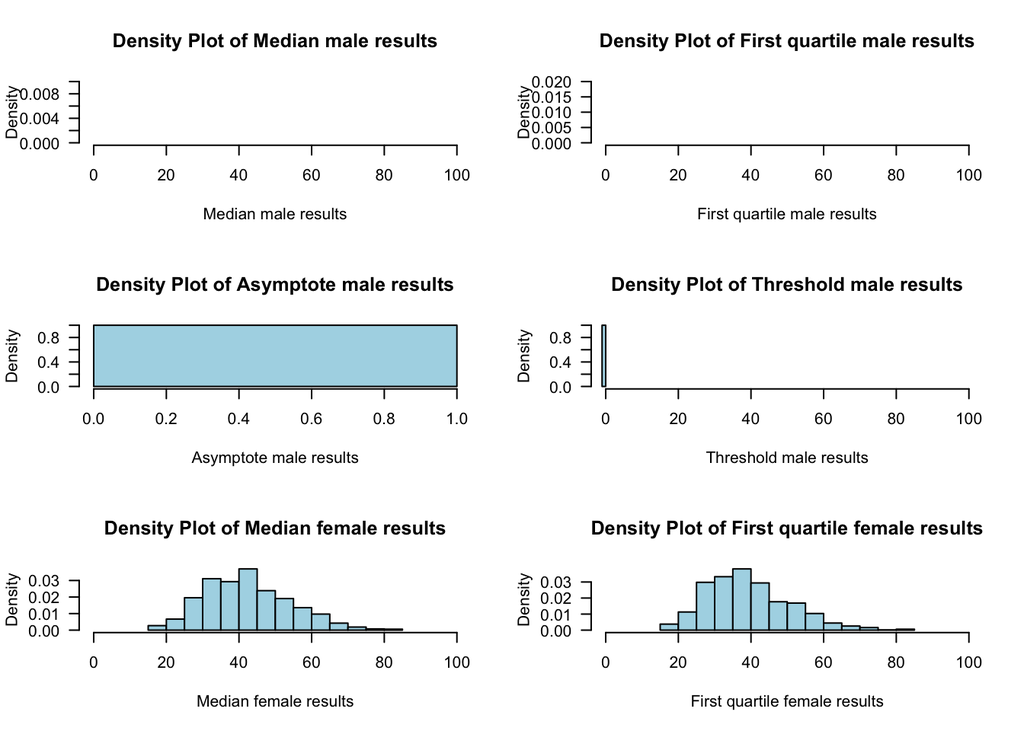

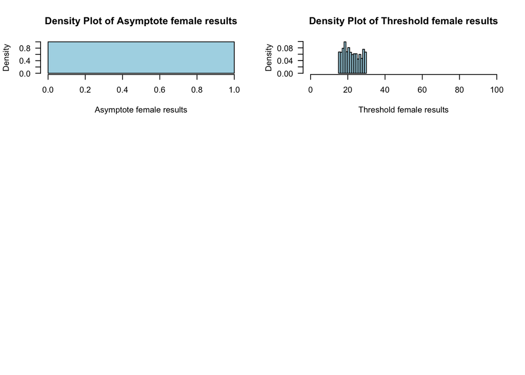

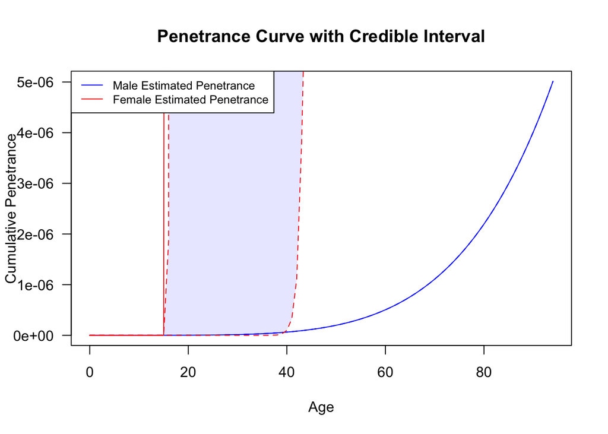

```r
dat<- simFamilies_C_1000_nocen_selected300

# Data Prep
for (i in seq_along(dat)) {
    if ("ID" %in% colnames(dat[[i]])) {
        colnames(dat[[i]])[colnames(dat[[i]]) == "PedigreeID"] <- "FamilyID"
    }
}

#  Data Prep
for (i in seq_along(dat)) {
    if ("ID" %in% colnames(dat[[i]])) {
        colnames(dat[[i]])[colnames(dat[[i]]) == "ID"] <- "SubjectID"
    }
}

for (i in seq_along(dat)) {
    # Add a new column "PedigreeID" with the list number
    dat[[i]]$PedigreeID <- i
}

# Exploring different priors
prior_params_BRCA1 <- list(
    asymptote = list(g1 = 900, g2 = 100),
    threshold = list(min = 15, max = 30),
    median = list(m1 = 2, m2 = 2),
    first_quartile = list(q1 = 6, q2 = 3)
)

# Run Estimation procedure with default prior setting
# Main Estimation for Female
out_sim_10k_simC300 <- PenEstim(
    data = dat,
    cancer_type = "Breast", gene_input = "BRCA1", n_chains = 4, n_iter_per_chain = 2000,
    prior_params = prior_params_BRCA1, af = 0.9, burn_in = 0.1, sex = "Female", median_max = FALSE
)
```

```r
# print summary stats
out_sim_10k_simC300$summary_stats
```

```
  Median_Male  Median_Female   Threshold_Male Threshold_Female
 Min.   :950   Min.   :16.57   Min.   :0      Min.   :15.00
 1st Qu.:950   1st Qu.:32.81   1st Qu.:0      1st Qu.:18.38
 Median :950   Median :41.30   Median :0      Median :21.66
 Mean   :950   Mean   :42.28   Mean   :0      Mean   :22.12
 3rd Qu.:950   3rd Qu.:49.83   3rd Qu.:0      3rd Qu.:25.95
 Max.   :950   Max.   :83.98   Max.   :0      Max.   :29.98
 First_Quartile_Male First_Quartile_Female Asymptote_Male Asymptote_Female
 Min.   :800         Min.   :16.21         Min.   :1      Min.   :1
 1st Qu.:800         1st Qu.:30.74         1st Qu.:1      1st Qu.:1
 Median :800         Median :38.15         Median :1      Median :1
 Mean   :800         Mean   :39.32         Mean   :1      Mean   :1
 3rd Qu.:800         3rd Qu.:46.19         3rd Qu.:1      3rd Qu.:1
 Max.   :800         Max.   :82.71         Max.   :1      Max.   :1
```

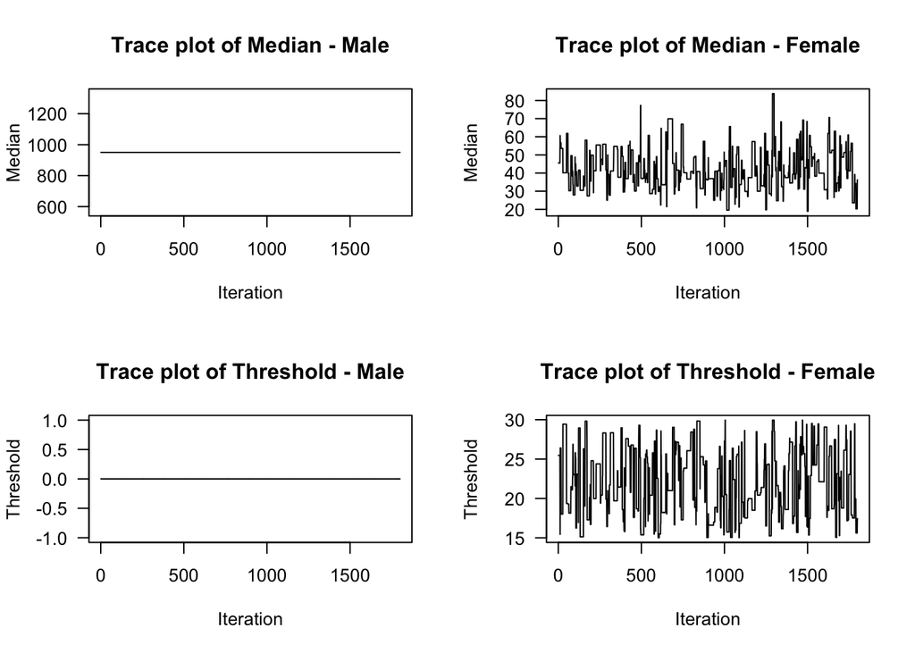

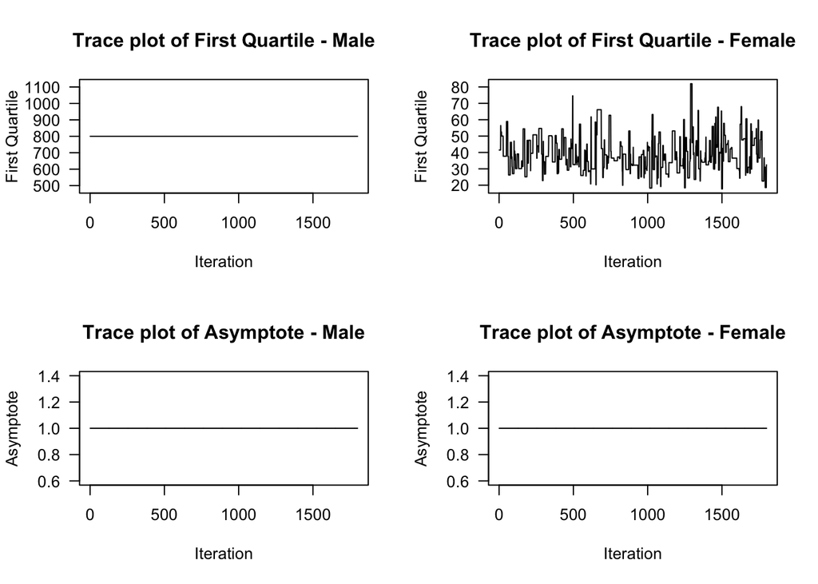

```r
plot_traceSingle(out_sim_10k_simC300$results[[1]])
```

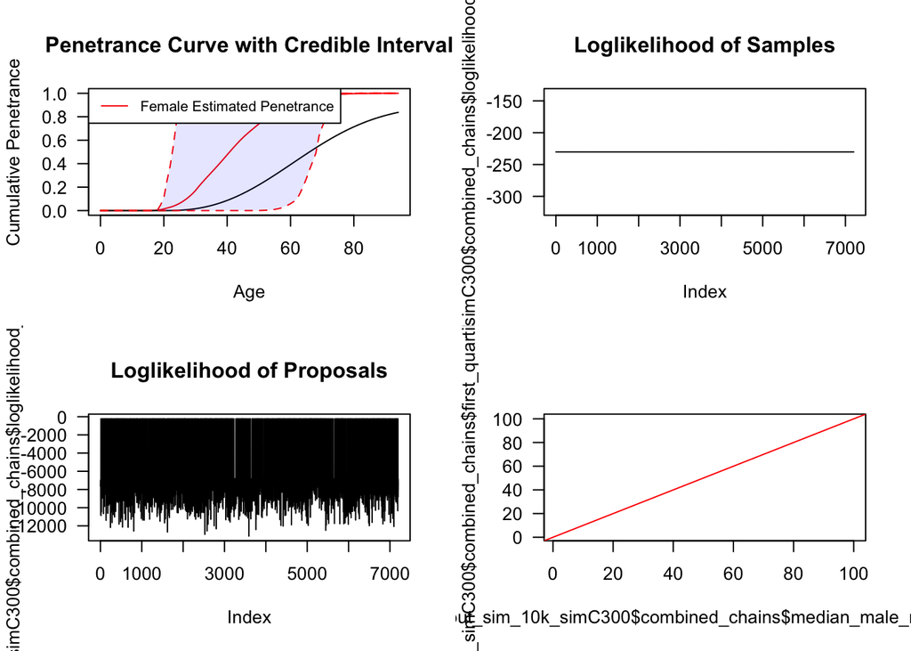

```r
plot_penetrance_sim(out_sim_10k_simC300$combined_chains, prob = 0.95, max_age = 94, sex = "Female",2.5,50,20,0.9)
plot(out_sim_10k_simC300$combined_chains$loglikelihood_current_results, type = "l", main = "Loglikelihood of Samples")
plot(out_sim_10k_simC300$combined_chains$loglikelihood_proposal_results, type = "l", main = "Loglikelihood of Proposals")

# Plot the running mean
#runFQ<- running_mean(out_sim_10k_simC300$results[[1]]$first_quartile_msamples)
#runMed <- running_mean(out_sim_10k_simC300$results[[1]]$median_samples)
#runThreshold <- running_mean(out_sim_10k_simC300$results[[1]]$threshold_samples)
#runAsy <- running_mean(out_sim_10k_simC300$results[[1]]$asymptote_samples)

# Plot running mean
#plot(runFQ, type = "l", xlab = "Iteration", ylab = "Running Mean", main = "Running Mean of First Quartile Samples")
#plot(runMed, type = "l", xlab = "Iteration", ylab = "Running Mean", main = "Running Mean of Median Samples")
#plot(runThreshold, type = "l", xlab = "Iteration", ylab = "Running Mean", main = "Running Mean of Threshold Samples")
#plot(runAsy, type = "l", xlab = "Iteration", ylab = "Running Mean", main = "Running Mean of Asymptote Samples")

# Plot the running var
#runVFQ<- running_variance(out_sim_10k_simC300$results[[1]]$first_quartile_samples)
#runVMed <- running_variance(out_sim_10k_simC300$results[[1]]$median_samples)
#runVThreshold <- running_variance(out_sim_10k_simC300$results[[1]]$threshold_samples)
#runVAsy <- running_variance(out_sim_10k_simC300$results[[1]]$asymptote_samples)

# Plot running var
#plot(runVFQ, type = "l", xlab = "Iteration", ylab = "Running Mean", main = "Running Var of First Quartile Samples")
#plot(runVMed, type = "l", xlab = "Iteration", ylab = "Running Mean", main = "Running Var of Median Samples")
#plot(runVThreshold, type = "l", xlab = "Iteration", ylab = "Running Mean", main = "Running Var of Threshold Samples")
#plot(runVAsy, type = "l", xlab = "Iteration", ylab = "Running Mean", main = "Running Var of Asymptote Samples")


  # Autocorrelation plots
#acf(out_sim_10k_simC300$results[[1]]$first_quartile_male_samples, main = "ACF of First Quartile - Male")
#acf(out_sim_10k_simC300$results[[1]]$first_quartile_female_samples, main = "ACF of First Quartile - Female")
#acf(out_sim_10k_simC300$results[[1]]$median_male_samples, main = "ACF of Median - Male")
#acf(out_sim_10k_simC300$results[[1]]$median_female_samples, main = "ACF of Median - Female")
#acf(out_sim_10k_simC300$results[[1]]$threshold_male_samples, main = "ACF of Threshold - Male")
#acf(out_sim_10k_simC300$results[[1]]$threshold_female_samples, main = "ACF of Threshold - Female")
#acf(out_sim_10k_simC300$results[[1]]$asymptote_male_samples, main = "ACF of Asymptote - Male")
#acf(out_sim_10k_simC300$results[[1]]$asymptote_female_samples, main = "ACF of Asymptote - Female")

# plot the scatterplot with the median and first quartile
plot(out_sim_10k_simC300$combined_chains$median_male_results, out_sim_10k_simC300$combined_chains$first_quartile_male_results, xlim = c(1,100), ylim = c(1,100))
abline(a=0, b=1, col="red") # This draws a red line with slope 1 passing through the origin
```

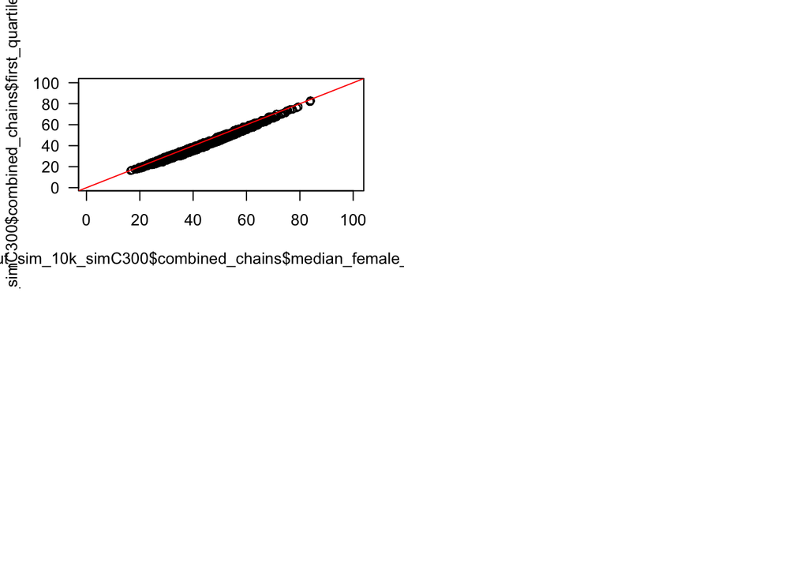

```r
plot(out_sim_10k_simC300$combined_chains$median_female_results, out_sim_10k_simC300$combined_chains$first_quartile_female_results, xlim = c(1,100), ylim = c(1,100))
abline(a=0, b=1, col="red") # This draws a red line with slope 1 passing through the origin
```

# Families Sim3 - Censored - Fixed Asymptote

```
Rejection rates:  0.9902 0.989 0.9868 0.9904
```

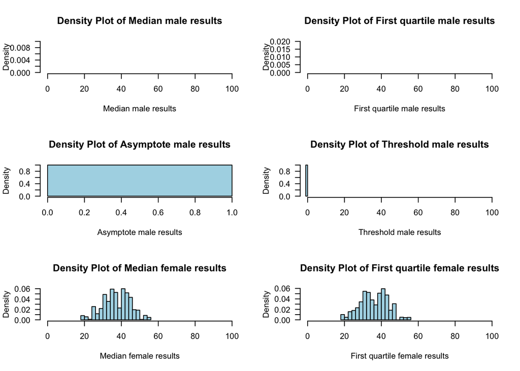

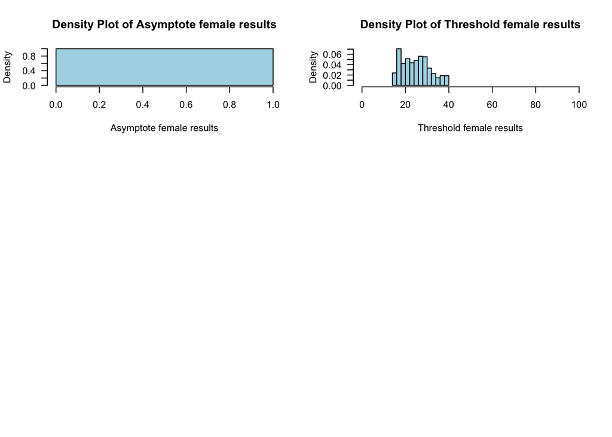

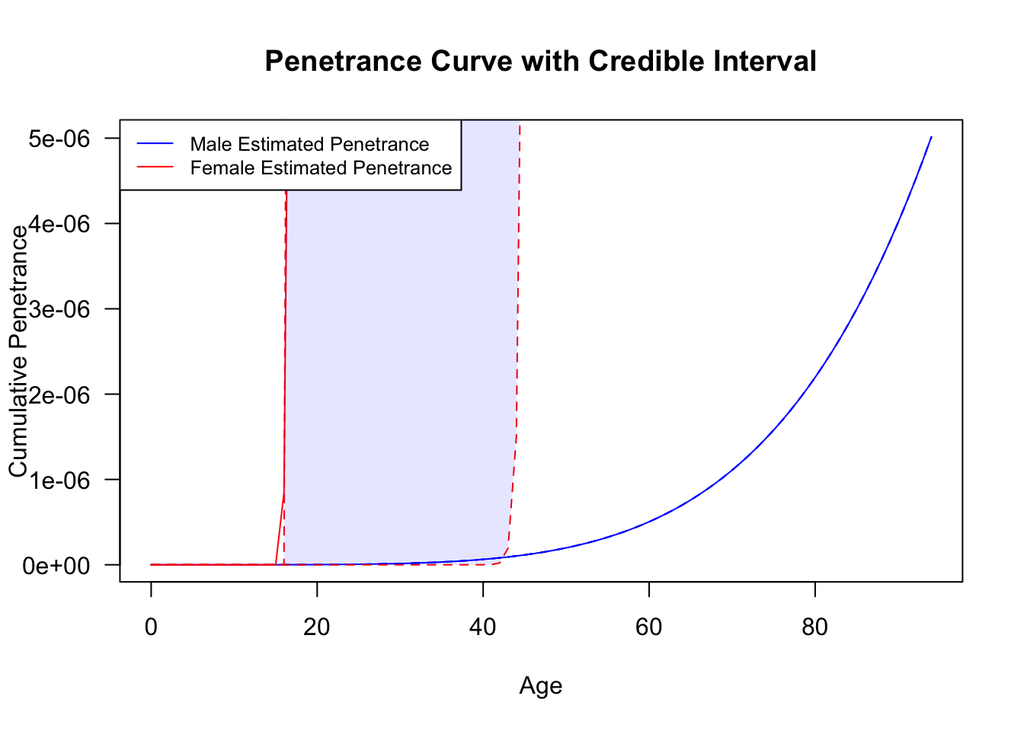

```r
dat <- simfamilies_sim3

# Data Prep
for (i in seq_along(dat)) {
    if ("ID" %in% colnames(dat[[i]])) {
        colnames(dat[[i]])[colnames(dat[[i]]) == "PedigreeID"] <- "FamilyID"
    }
}

#  Data Prep
for (i in seq_along(dat)) {
    if ("ID" %in% colnames(dat[[i]])) {
        colnames(dat[[i]])[colnames(dat[[i]]) == "ID"] <- "SubjectID"
    }
}

for (i in seq_along(dat)) {
    # Add a new column "PedigreeID" with the list number
    dat[[i]]$PedigreeID <- i
}

# Exploring different priors
prior_params_BRCA1 <- list(
    asymptote = list(g1 = 900, g2 = 100),
    threshold = list(min = 15, max = 40),
    median = list(m1 = 3, m2 = 2),
    first_quartile = list(q1 = 6, q2 = 3)
)

# Run Estimation procedure with default prior setting
# Main Estimation for Female
out_sim_3 <- PenEstim(
    data = dat,
    cancer_type = "Breast", gene_input = "BRCA1", n_chains = 4, n_iter_per_chain = 5000,
    prior_params = prior_params_BRCA1, af = 0.1, burn_in = 0.1, sex = "Female", median_max = FALSE
)
```

```r
save(out_sim_3, file = "out_sim_3.Rdata")

# print summary stats
out_sim_3$summary_stats
```

```
  Median_Male  Median_Female   Threshold_Male Threshold_Female
 Min.   :950   Min.   :18.59   Min.   :0      Min.   :15.01
 1st Qu.:950   1st Qu.:32.04   1st Qu.:0      1st Qu.:19.52
 Median :950   Median :36.74   Median :0      Median :24.78
 Mean   :950   Mean   :37.30   Mean   :0      Mean   :24.94
 3rd Qu.:950   3rd Qu.:42.67   3rd Qu.:0      3rd Qu.:29.14
 Max.   :950   Max.   :54.92   Max.   :0      Max.   :39.98
 First_Quartile_Male First_Quartile_Female Asymptote_Male Asymptote_Female
 Min.   :800         Min.   :18.16         Min.   :1      Min.   :1
 1st Qu.:800         1st Qu.:30.24         1st Qu.:1      1st Qu.:1
 Median :800         Median :35.51         Median :1      Median :1
 Mean   :800         Mean   :35.84         Mean   :1      Mean   :1
 3rd Qu.:800         3rd Qu.:41.02         3rd Qu.:1      3rd Qu.:1
 Max.   :800         Max.   :54.56         Max.   :1      Max.   :1
```

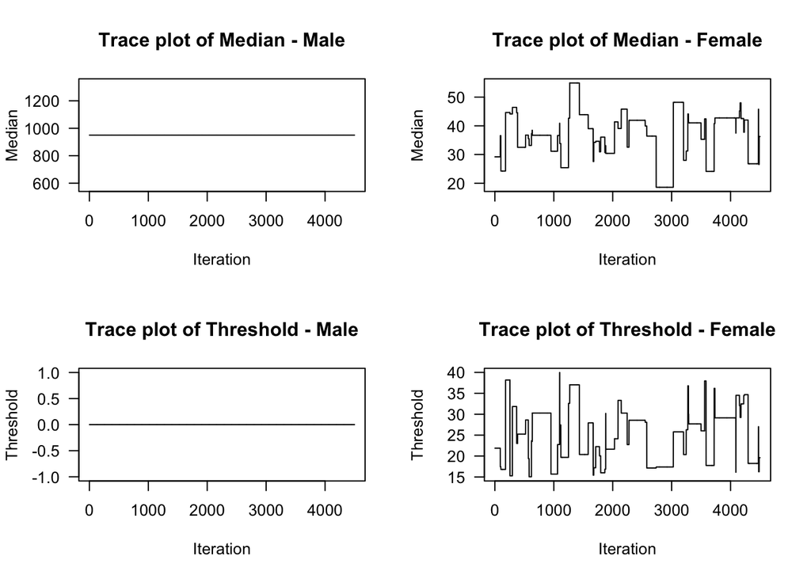

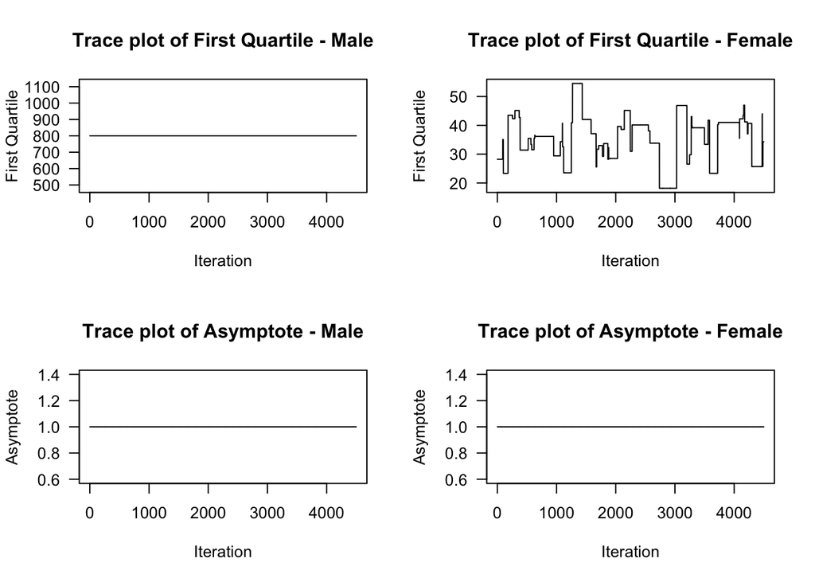

```r
plot_traceSingle(out_sim_3$results[[3]])
```

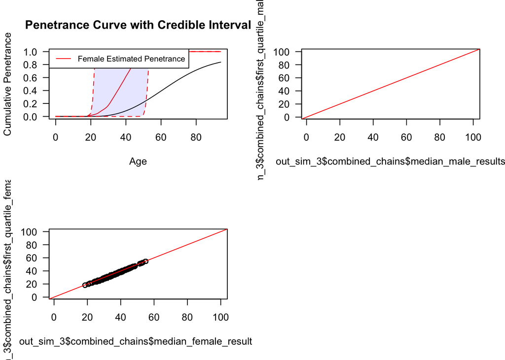

```r
plot_penetrance_sim(out_sim_3$combined_chains, prob = 0.95, max_age = 94,"Female",2.5,50,20,0.9)

# Plot the running mean
#runFQ<- running_mean(out_sim_3$results[[1]]$first_quartile_samples)
#runMed <- running_mean(out_sim_3$results[[1]]$median_samples)
#runThreshold <- running_mean(out_sim_3$results[[1]]$threshold_samples)
#runAsy <- running_mean(out_sim_3$results[[1]]$asymptote_samples)

# Plot running mean
#plot(runFQ, type = "l", xlab = "Iteration", ylab = "Running Mean", main = "Running Mean of First Quartile Samples")
#plot(runMed, type = "l", xlab = "Iteration", ylab = "Running Mean", main = "Running Mean of Median Samples")
#plot(runThreshold, type = "l", xlab = "Iteration", ylab = "Running Mean", main = "Running Mean of Threshold Samples")
#plot(runAsy, type = "l", xlab = "Iteration", ylab = "Running Mean", main = "Running Mean of Asymptote Samples")

# Plot the running var
#runVFQ<- running_variance(out_sim_3$results[[1]]$first_quartile_samples)
#runVMed <- running_variance(out_sim_3$results[[1]]$median_samples)
#runVThreshold <- running_variance(out_sim_3$results[[1]]$threshold_samples)
#runVAsy <- running_variance(out_sim_3$results[[1]]$asymptote_samples)

# Plot running var
#plot(runVFQ, type = "l", xlab = "Iteration", ylab = "Running Mean", main = "Running Var of First Quartile Samples")
#plot(runVMed, type = "l", xlab = "Iteration", ylab = "Running Mean", main = "Running Var of Median Samples")
#plot(runVThreshold, type = "l", xlab = "Iteration", ylab = "Running Mean", main = "Running Var of Threshold Samples")
#plot(runVAsy, type = "l", xlab = "Iteration", ylab = "Running Mean", main = "Running Var of Asymptote Samples")

# Autocorrelation plots
#acf(out_sim_3$results[[1]]$first_quartile_male_samples, main = "ACF of First Quartile - Male")
#acf(out_sim_3$results[[1]]$first_quartile_female_samples, main = "ACF of First Quartile - Female")
#acf(out_sim_3$results[[1]]$median_male_samples, main = "ACF of Median - Male")
#acf(out_sim_3$results[[1]]$median_female_samples, main = "ACF of Median - Female")
#acf(out_sim_3$results[[1]]$threshold_male_samples, main = "ACF of Threshold - Male")
#acf(out_sim_3$results[[1]]$threshold_female_samples, main = "ACF of Threshold - Female")
#acf(out_sim_3$results[[1]]$asymptote_male_samples, main = "ACF of Asymptote - Male")
#acf(out_sim_3$results[[1]]$asymptote_female_samples, main = "ACF of Asymptote - Female")

# plot the scatterplot with the median and first quartile
plot(out_sim_3$combined_chains$median_male_results, out_sim_3$combined_chains$first_quartile_male_results, xlim = c(1,100), ylim = c(1,100))
abline(a=0, b=1, col="red") # This draws a red line with slope 1 passing through the origin
plot(out_sim_3$combined_chains$median_female_results, out_sim_3$combined_chains$first_quartile_female_results, xlim = c(1,100), ylim = c(1,100))
abline(a=0, b=1, col="red") # This draws a red line with slope 1 passing through the origin
```

# Families Sim3 - Uncensored - Fixed Asymptote

```
Rejection rates:  0.8328 0.836 0.8344 0.8242
```

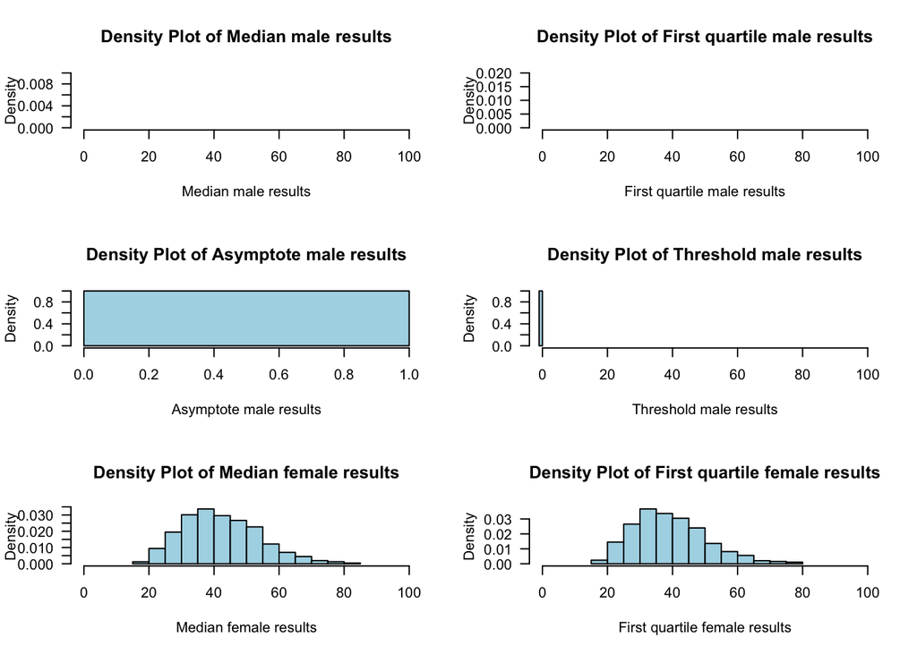

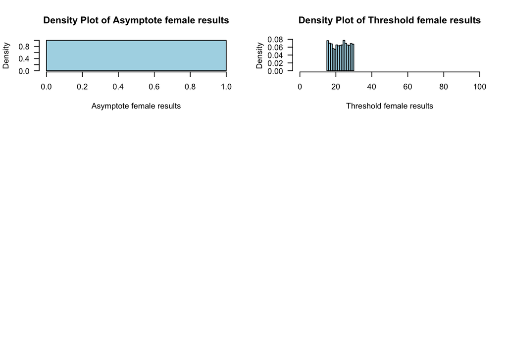

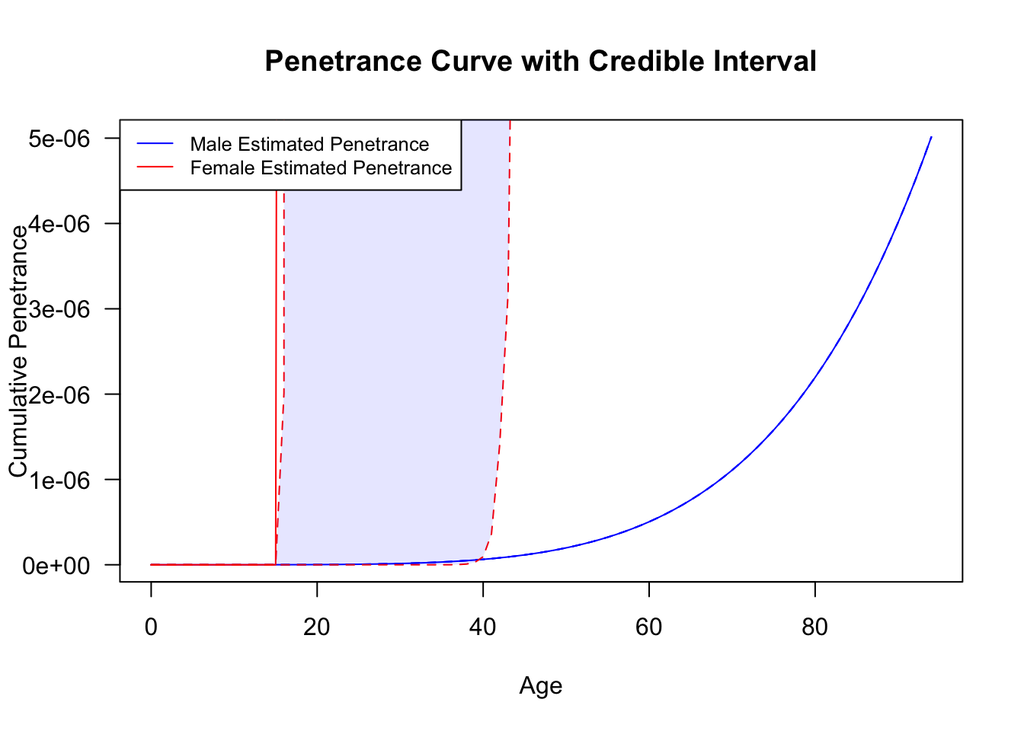

```r
dat <- simfamilies_sim3_UC

# Data Prep
for (i in seq_along(dat)) {
    if ("ID" %in% colnames(dat[[i]])) {
        colnames(dat[[i]])[colnames(dat[[i]]) == "PedigreeID"] <- "FamilyID"
    }
}

#  Data Prep
for (i in seq_along(dat)) {
    if ("ID" %in% colnames(dat[[i]])) {
        colnames(dat[[i]])[colnames(dat[[i]]) == "ID"] <- "SubjectID"
    }
}

for (i in seq_along(dat)) {
    # Add a new column "PedigreeID" with the list number
    dat[[i]]$PedigreeID <- i
}

# Exploring different priors
prior_params_BRCA1 <- list(
    asymptote = list(g1 = 9, g2 = 100),
    threshold = list(min = 15, max = 30),
    median = list(m1 = 2, m2 = 2),
    first_quartile = list(q1 = 6, q2 = 3)
)

# Run Estimation procedure with default prior setting
# Main Estimation for Female
out_sim_3 <- PenEstim(
    data = dat,
    cancer_type = "Breast", gene_input = "BRCA1", n_chains = 4, n_iter_per_chain = 5000,
    prior_params = prior_params_BRCA1, af = 0.1, burn_in = 0, median_max = FALSE
)
```

```r
save(out_sim_3, file = "out_sim_3.Rdata")

# print summary stats
out_sim_3$summary_stats
```

```
  Median_Male  Median_Female   Threshold_Male Threshold_Female
 Min.   :950   Min.   :17.40   Min.   :0      Min.   :15.01
 1st Qu.:950   1st Qu.:33.36   1st Qu.:0      1st Qu.:18.64
 Median :950   Median :40.87   Median :0      Median :22.65
 Mean   :950   Mean   :42.13   Mean   :0      Mean   :22.51
 3rd Qu.:950   3rd Qu.:49.99   3rd Qu.:0      3rd Qu.:26.22
 Max.   :950   Max.   :81.22   Max.   :0      Max.   :30.00
 First_Quartile_Male First_Quartile_Female Asymptote_Male Asymptote_Female
 Min.   :800         Min.   :16.76         Min.   :1      Min.   :1
 1st Qu.:800         1st Qu.:30.91         1st Qu.:1      1st Qu.:1
 Median :800         Median :37.63         Median :1      Median :1
 Mean   :800         Mean   :39.22         Mean   :1      Mean   :1
 3rd Qu.:800         3rd Qu.:46.40         3rd Qu.:1      3rd Qu.:1
 Max.   :800         Max.   :79.52         Max.   :1      Max.   :1
```

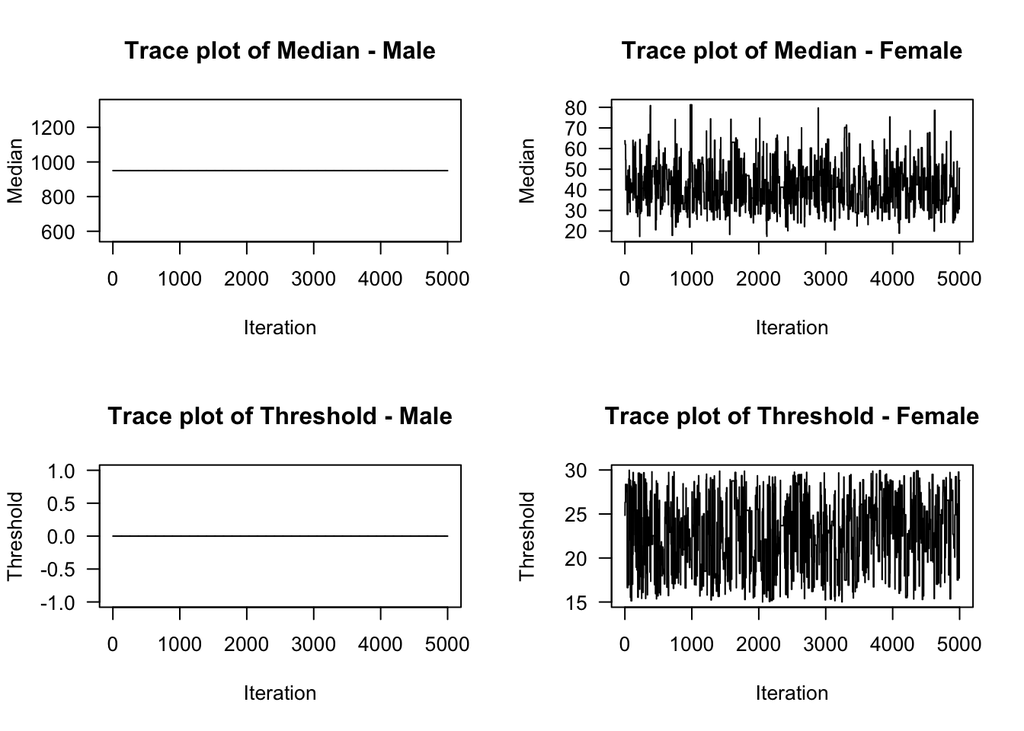

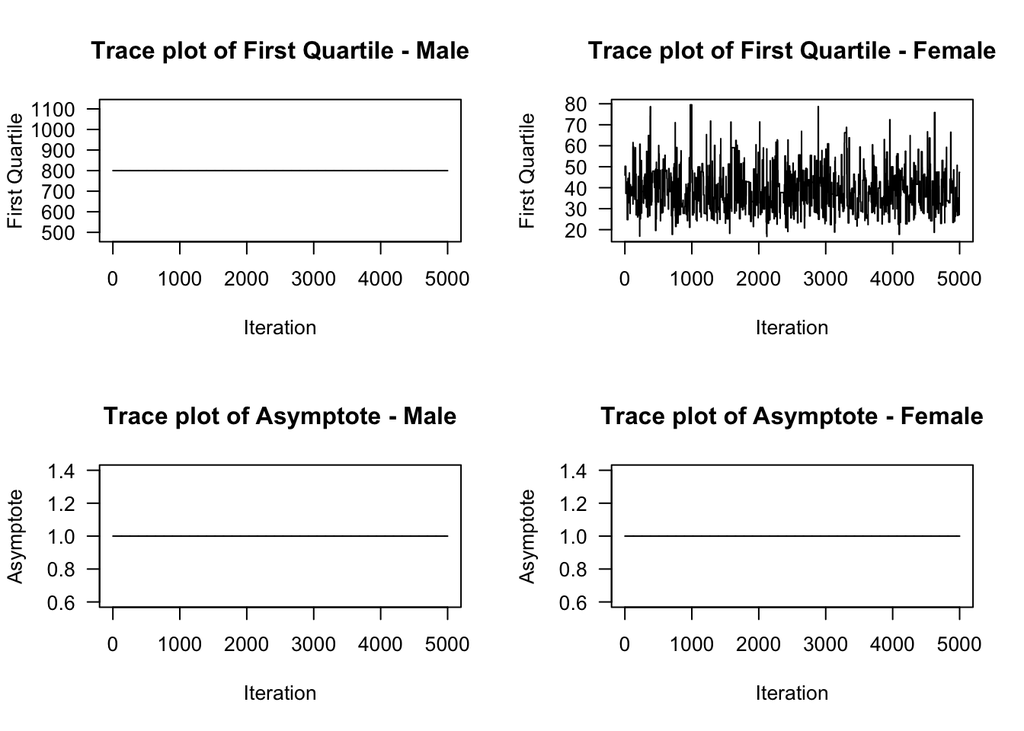

```r
plot_traceSingle(out_sim_3$results[[1]])
```

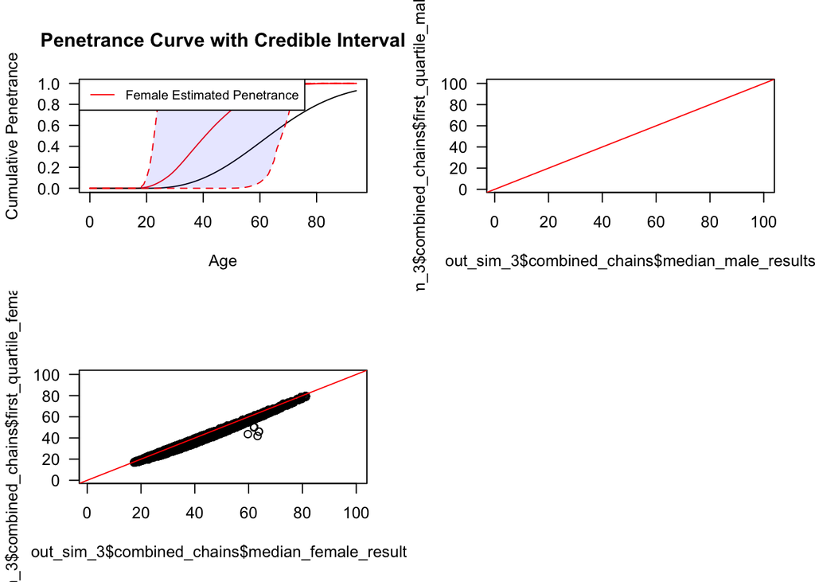

```r
plot_penetrance_sim(out_sim_3$combined_chains, prob = 0.95, max_age = 94,"Female",2.5,50,20,1)

# Plot the running mean
#runFQ<- running_mean(out_sim_3$results[[1]]$first_quartile_samples)
#runMed <- running_mean(out_sim_3$results[[1]]$median_samples)
#runThreshold <- running_mean(out_sim_3$results[[1]]$threshold_samples)
#runAsy <- running_mean(out_sim_3$results[[1]]$asymptote_samples)

# Plot running mean
#plot(runFQ, type = "l", xlab = "Iteration", ylab = "Running Mean", main = "Running Mean of First Quartile Samples")
#plot(runMed, type = "l", xlab = "Iteration", ylab = "Running Mean", main = "Running Mean of Median Samples")
#plot(runThreshold, type = "l", xlab = "Iteration", ylab = "Running Mean", main = "Running Mean of Threshold Samples")
#plot(runAsy, type = "l", xlab = "Iteration", ylab = "Running Mean", main = "Running Mean of Asymptote Samples")

# Plot the running var
#runVFQ<- running_variance(out_sim_3$results[[1]]$first_quartile_samples)
#runVMed <- running_variance(out_sim_3$results[[1]]$median_samples)
#runVThreshold <- running_variance(out_sim_3$results[[1]]$threshold_samples)
#runVAsy <- running_variance(out_sim_3$results[[1]]$asymptote_samples)

# Plot running var
#plot(runVFQ, type = "l", xlab = "Iteration", ylab = "Running Mean", main = "Running Var of First Quartile Samples")
#plot(runVMed, type = "l", xlab = "Iteration", ylab = "Running Mean", main = "Running Var of Median Samples")
#plot(runVThreshold, type = "l", xlab = "Iteration", ylab = "Running Mean", main = "Running Var of Threshold Samples")
#plot(runVAsy, type = "l", xlab = "Iteration", ylab = "Running Mean", main = "Running Var of Asymptote Samples")

# Autocorrelation plots
#acf(out_sim_3$results[[1]]$first_quartile_male_samples, main = "ACF of First Quartile - Male")
#acf(out_sim_3$results[[1]]$first_quartile_female_samples, main = "ACF of First Quartile - Female")
#acf(out_sim_3$results[[1]]$median_male_samples, main = "ACF of Median - Male")
#acf(out_sim_3$results[[1]]$median_female_samples, main = "ACF of Median - Female")
#acf(out_sim_3$results[[1]]$threshold_male_samples, main = "ACF of Threshold - Male")
#acf(out_sim_3$results[[1]]$threshold_female_samples, main = "ACF of Threshold - Female")
#acf(out_sim_3$results[[1]]$asymptote_male_samples, main = "ACF of Asymptote - Male")
#acf(out_sim_3$results[[1]]$asymptote_female_samples, main = "ACF of Asymptote - Female")

# plot the scatterplot with the median and first quartile
plot(out_sim_3$combined_chains$median_male_results, out_sim_3$combined_chains$first_quartile_male_results, xlim = c(1,100), ylim = c(1,100))
abline(a=0, b=1, col="red") # This draws a red line with slope 1 passing through the origin
plot(out_sim_3$combined_chains$median_female_results, out_sim_3$combined_chains$first_quartile_female_results, xlim = c(1,100), ylim = c(1,100))
abline(a=0, b=1, col="red") # This draws a red line with slope 1 passing through the origin
```